# Part I - Loan Data From Prosper

### What is the relationship among Loan Term, Prosper Rating and Borrower APR

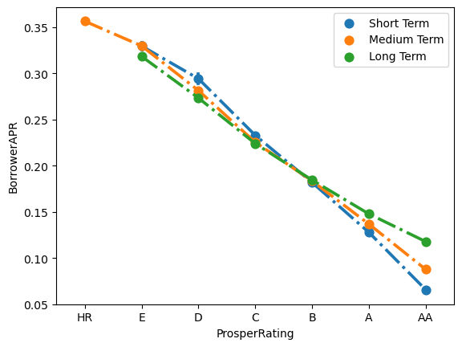

```python
sb.pointplot(data=df_Newloan_clean,x='ProsperRating', y='BorrowerAPR',order=None,hue='LoanTerm',linestyles = '-.')
plt.legend()
plt.show()
```

### What is the relationship among Prosper Rating, Borrower APR and Borrower Homeowner Status

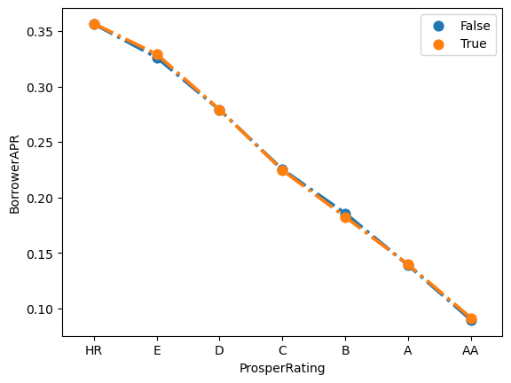

```python
sb.pointplot(data=df_Newloan_clean,x='ProsperRating', y='BorrowerAPR',order=None,hue='IsBorrowerHomeowner',linestyles = '-.')
plt.legend()
plt.show()
```

#### Observation

> Whether a Borrower is a homeowner or not, the Prosper Rating has a negative relation with the Borrower APR

### What is the relationship among Prosper Rating, Loan Original Amount and Borrower Homeowner Status

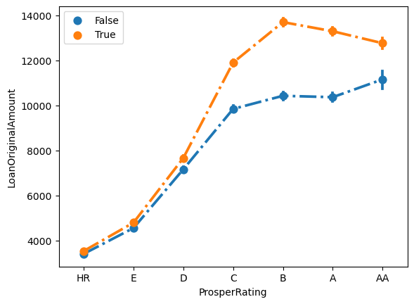

```python
sb.pointplot(data=df_Newloan_clean,x='ProsperRating', y='LoanOriginalAmount',order=None,hue='IsBorrowerHomeowner',linestyles = '-.')
plt.legend()
plt.show()
```

#### Observations

> 1. Prosper Rating has a positive relation with Loan Original Amount
> 2. As Prosper Rating increases and Loan Original Amount increases, Homeowners and Non-homeowners diverges. This means Homeowners with high ratings takes high Loan Amount done Non-homeowners with same ratings

### What is the relationship among Prosper Rating, Monthly Income and Borrower Homeowner Status

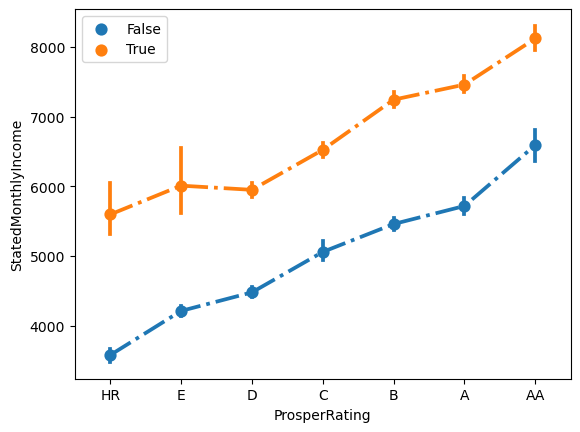

```python
sb.pointplot(data=df_Newloan_clean,x='ProsperRating', y='StatedMonthlyIncome',order=None,hue='IsBorrowerHomeowner',linestyles = '-.')
plt.legend()
plt.show()
```

#### Observations

> 1. Prosper Rating is positively related with Monthly Income
> 2. Income of Homeowners are higher than Non-homeowners.
> 3. The lower the rating, the higher the difference in income between Homeowners and Non-homeowners
> 4. The higher the rating, the constant the difference in income between Homeownera nad Non-homeowners

### What is the relationship among Loan Term, Loan Amount and Borrower Homeowner Status

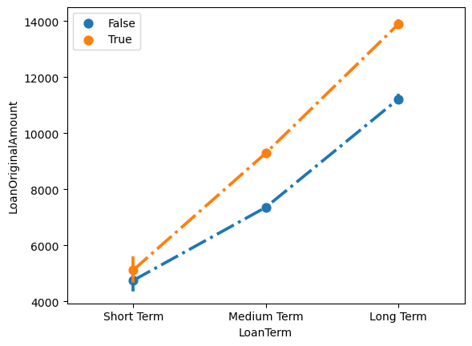

```python
sb.pointplot(data=df_Newloan_clean,x='LoanTerm', y='LoanOriginalAmount',order=None,hue='IsBorrowerHomeowner',linestyles = '-.')
plt.legend()
plt.show()
```

#### Observations

> 1. Loan Term has a positive relation with Loan Original Amount
> 2. Homeowners have higher Loan Amount than Non-homeowners
> 3. As Loan Term increases, the difference of Loan Amount between Homeowners and Non-homowners diverges.

### What is the relationship among Listing Category, Loan Amount and Borrower Homeowner Status

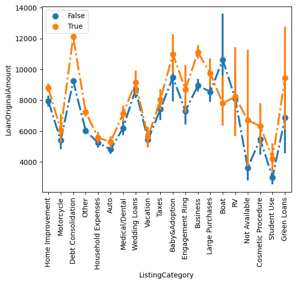

```python
sb.pointplot(data=df_Newloan_clean,x='ListingCategory', y='LoanOriginalAmount',order=None,hue='IsBorrowerHomeowner',linestyles = '-.')
plt.legend()
plt.xticks(rotation=90)
plt.show()
```

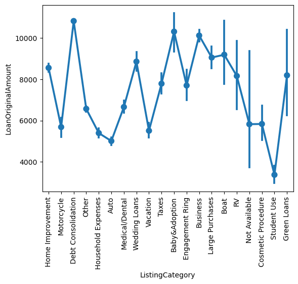

```python
sb.pointplot(data=df_Newloan_clean,x='ListingCategory', y='LoanOriginalAmount')
plt.xticks(rotation=90)
plt.show()
```

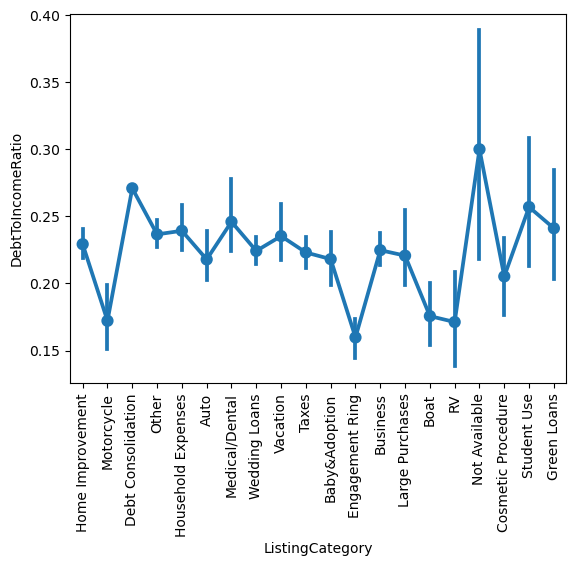

```python
sb.pointplot(data=df_Newloan_clean,x='ListingCategory', y='DebtToIncomeRatio')
plt.xticks(rotation=90)
plt.show()
```

#### Observation

> Loan Amount for Homeowners are higher than that of Non-homeowners for all the Listing Categories except for Boat